# Repruducible Research Course Project 1

## Imputing missing values:

1. Calculate and report the total number of missing values in the dataset (i.e. the total number of rows with 𝙽𝙰s)

```r
sum(is.na(df$steps))
```

```
## [1] 2304
```

2. Devise a strategy for filling in all of the missing values in the dataset.

```r
df.filled <- df
filtered <- is.na(df$steps)
by_interval <- tapply(df$steps, df$interval, median, na.rm=TRUE)
df.filled$steps[filtered] <- by_interval[as.character(df$interval[filtered])]
```

3. Make a histogram of the total number of steps taken each day and Calculate and report the mean and median total number of steps taken per day.

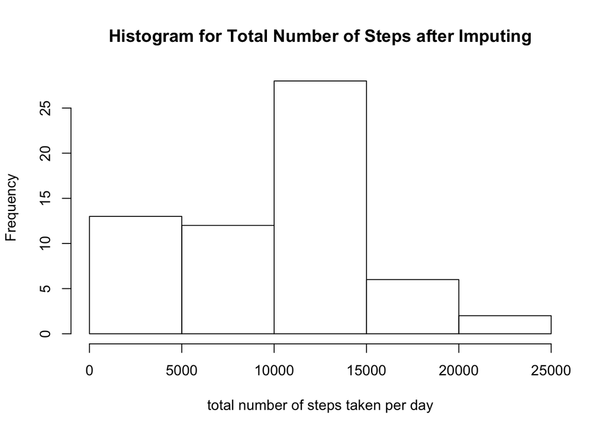

```r
total_step <- aggregate(steps~date, df.filled, sum, na.rm = TRUE)
hist(total_step$steps,
     main="Histogram for Total Number of Steps after Imputing",
     xlab="total number of steps taken per day")
```

```r
mean(total_step$steps)
```

```
## [1] 9503.869
```

```r
median(total_step$steps)
```

```
## [1] 10395
```

## Are there differences in activity patterns between weekdays and weekends?

1. Create a new factor variable in the dataset with two levels – “weekday” and “weekend” indicating whether a given date is a weekday or weekend day.

```r
df$date <- as.Date(strptime(df$date, format="%Y-%m-%d"))
df$datetype <- sapply(df$date, function(x) {
                            if (weekdays(x) == "Saturday" | weekdays(x) =="Sunday")
                              {y <- "Weekend"} else
                              {y <- "Weekday"}
                              y
                            })
head(df)
```

```
##   steps       date interval datetype
## 1    NA 2012-10-01        0  Weekday
## 2    NA 2012-10-01        5  Weekday
## 3    NA 2012-10-01       10  Weekday
## 4    NA 2012-10-01       15  Weekday
## 5    NA 2012-10-01       20  Weekday
## 6    NA 2012-10-01       25  Weekday
```

2. Make a panel plot containing a time series plot (i.e. 𝚝𝚢𝚙𝚎 = “𝚕”) of the 5-minute interval (x-axis) and the average number of steps taken, averaged across all weekday days or weekend days (y-axis).

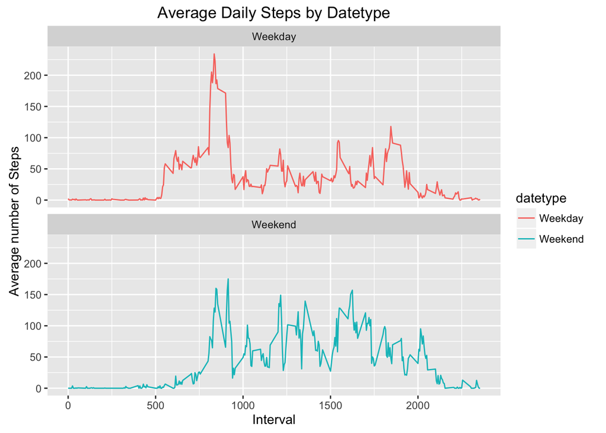

```r
library(ggplot2)
by_date <- aggregate(steps~interval + datetype, df, mean, na.rm = TRUE)
plot<- ggplot(by_date, aes(x = interval , y = steps, color = datetype)) +
       geom_line() +
       labs(title = "Average Daily Steps by Datetype", x = "Interval", y = "Average number of Steps") +
       facet_wrap(~datetype, ncol = 1, nrow=2)
print(plot)
```